# 52414 - lab 1

52414

4/4/2020

# *Lab 1: Basic Data Wrangling*

**Contents**:

- Q0) Submission Instructions
- Q1) Data Preparation and Manipulation
- Q2) Analysis of Daily New Corona Cases and Deaths
- Q3) Preparing and Analyzing the World Bank Data
- Q4) Joining the Datasets
- Q5) Open Question

### Submission Instructions

This lab will be submitted in pairs using GitHub (if you don’t have a pair, please contact us).  
Please follow the steps in the [GitHub-Classroom Lab 1](https://classroom.github.com/g/oSZNtHq4) to create your group’s Lab 1 repository.  
**Important: your team’s name must be `FamilyName1_Name1_and_FamilyName2_Name2`**.  
You can collaborate with your partner using the git environment; You can either make commits straight to master, or create individual branches (recommended). However, once done, be sure to merge your branches to master - you will be graded using the most recent master version - your last push and merge before the deadline.  
**Please do not open/review other peoples’ repositories - we will be notified by GitHub if you do.**

Your final push should include this Rmd file (with your answers) together with the html file that is outputted automatically by knitr when you knit the Rmd. Anything else will be disregarded. In addition, please adhere to the following file format:  
`Lab_2_FamilyName1_Name1_and_FamilyName2_Name2.Rmd/html`

## A Deeper Dive Into John’s Hopkins Corona Database

The John’s Hopkins Novel Corona Virus (COVID-19) epidemiological data is compiled by the Johns Hopkins University Center for Systems Science and Engineering (JHU CCSE) from various sources.  
The dataset contains data since 22nd of January 2020. For the data and more information about it, please visit [here](https://data.humdata.org/dataset/novel-coronavirus-2019-ncov-cases).

In this lab you will pick up where we left in lecture 2 and analyze the Corona cases and deaths data.

### Q1

### Data Preparation and Manipulation

(25 points)

1. We first prepare and aggregate the data.
1. First, load the `Corona Confirmed Cases Narrow`, the `Corona Confirmed Deaths Narrow`, and the `Corona Confirmed Recovered Narrow` datasets directly from the John’s Hopkins website.  
   The type of the `Date` variable should be date type. (2 pts)
2. Create new data-frames named `cases.agg`, `deaths.agg`, and `recovered.agg` which aggregate the `sum` of Corona cases, deaths, and recovered respectively over the different countries’ provinces. To do this, aggregate `Value` using only the country and date features, ignoring all other features (similarly to what has been shown in `lecture 2`).  
   To achieve the aggregation use the `aggregate` function. In addition, order the data-frame first by Country and then by Date (increasing order). The columns of each of the two resulting data-frames should be `Country.Region, Date, Value`. (5pts)
3. Repeat (b) using `tidyverse` and the pipe. Show that the outputs from the two methods are the same. (5pts)
4. Using the last day of March as a reference, create a single stacked bar-plot that visualizes the top 10 countries in terms of their Corona cases, and their respected Corona deaths and recovered cases stacked on top of the current sick people in three different colors (each stack should add up to total cases). Make sure that the first bar shows the number of confirmed Corona sick people (`sick = cases - deaths - recovered`). What is the biggest issue with the information presented in this plot? (13pts)

**Solution:**

```r
data_con = read.csv(url("https://data.humdata.org/hxlproxy/data/download/time_series_covid19_confirmed_global_narrow.csv?dest=data_edit&filter01=merge&merge-url01=https%3A%2F%2Fdocs.google.com%2Fspreadsheets%2Fd%2Fe%2F2PACX-1vTglKQRXpkKSErDiWG6ycqEth32MY0reMuVGhaslImLjfuLU0EUgyyu2e-3vKDArjqGX7dXEBV8FJ4f%2Fpub%3Fgid%3D1326629740%26single%3Dtrue%26output%3Dcsv&merge-keys01=%23country%2Bname&merge-tags01=%23country%2Bcode%2C%23region%2Bmain%2Bcode%2C%23region%2Bsub%2Bcode%2C%23region%2Bintermediate%2Bcode&filter02=merge&merge-url02=https%3A%2F%2Fdocs.google.com%2Fspreadsheets%2Fd%2Fe%2F2PACX-1vTglKQRXpkKSErDiWG6ycqEth32MY0reMuVGhaslImLjfuLU0EUgyyu2e-3vKDArjqGX7dXEBV8FJ4f%2Fpub%3Fgid%3D398158223%26single%3Dtrue%26output%3Dcsv&merge-keys02=%23adm1%2Bname&merge-tags02=%23country%2Bcode%2C%23region%2Bmain%2Bcode%2C%23region%2Bsub%2Bcode%2C%23region%2Bintermediate%2Bcode&merge-replace02=on&merge-overwrite02=on&filter03=explode&explode-header-att03=date&explode-value-att03=value&filter04=rename&rename-oldtag04=%23affected%2Bdate&rename-newtag04=%23date&rename-header04=Date&filter05=rename&rename-oldtag05=%23affected%2Bvalue&rename-newtag05=%23affected%2Binfected%2Bvalue%2Bnum&rename-header05=Value&filter06=clean&clean-date-tags06=%23date&filter07=sort&sort-tags07=%23date&sort-reverse07=on&filter08=sort&sort-tags08=%23country%2Bname%2C%23adm1%2Bname&tagger-match-all=on&tagger-default-tag=%23affected%2Blabel&tagger-01-header=province%2Fstate&tagger-01-tag=%23adm1%2Bname&tagger-02-header=country%2Fregion&tagger-02-tag=%23country%2Bname&tagger-03-header=lat&tagger-03-tag=%23geo%2Blat&tagger-04-header=long&tagger-04-tag=%23geo%2Blon&header-row=1&url=https%3A%2F%2Fraw.githubusercontent.com%2FCSSEGISandData%2FCOVID-19%2Fmaster%2Fcsse_covid_19_data%2Fcsse_covid_19_time_series%2Ftime_series_covid19_confirmed_global.csv"), comment.char = "#")
data_death = read.csv(url("https://data.humdata.org/hxlproxy/data/download/time_series_covid19_deaths_global_narrow.csv?dest=data_edit&filter01=merge&merge-url01=https%3A%2F%2Fdocs.google.com%2Fspreadsheets%2Fd%2Fe%2F2PACX-1vTglKQRXpkKSErDiWG6ycqEth32MY0reMuVGhaslImLjfuLU0EUgyyu2e-3vKDArjqGX7dXEBV8FJ4f%2Fpub%3Fgid%3D1326629740%26single%3Dtrue%26output%3Dcsv&merge-keys01=%23country%2Bname&merge-tags01=%23country%2Bcode%2C%23region%2Bmain%2Bcode%2C%23region%2Bsub%2Bcode%2C%23region%2Bintermediate%2Bcode&filter02=merge&merge-url02=https%3A%2F%2Fdocs.google.com%2Fspreadsheets%2Fd%2Fe%2F2PACX-1vTglKQRXpkKSErDiWG6ycqEth32MY0reMuVGhaslImLjfuLU0EUgyyu2e-3vKDArjqGX7dXEBV8FJ4f%2Fpub%3Fgid%3D398158223%26single%3Dtrue%26output%3Dcsv&merge-keys02=%23adm1%2Bname&merge-tags02=%23country%2Bcode%2C%23region%2Bmain%2Bcode%2C%23region%2Bsub%2Bcode%2C%23region%2Bintermediate%2Bcode&merge-replace02=on&merge-overwrite02=on&filter03=explode&explode-header-att03=date&explode-value-att03=value&filter04=rename&rename-oldtag04=%23affected%2Bdate&rename-newtag04=%23date&rename-header04=Date&filter05=rename&rename-oldtag05=%23affected%2Bvalue&rename-newtag05=%23affected%2Binfected%2Bvalue%2Bnum&rename-header05=Value&filter06=clean&clean-date-tags06=%23date&filter07=sort&sort-tags07=%23date&sort-reverse07=on&filter08=sort&sort-tags08=%23country%2Bname%2C%23adm1%2Bname&tagger-match-all=on&tagger-default-tag=%23affected%2Blabel&tagger-01-header=province%2Fstate&tagger-01-tag=%23adm1%2Bname&tagger-02-header=country%2Fregion&tagger-02-tag=%23country%2Bname&tagger-03-header=lat&tagger-03-tag=%23geo%2Blat&tagger-04-header=long&tagger-04-tag=%23geo%2Blon&header-row=1&url=https%3A%2F%2Fraw.githubusercontent.com%2FCSSEGISandData%2FCOVID-19%2Fmaster%2Fcsse_covid_19_data%2Fcsse_covid_19_time_series%2Ftime_series_covid19_deaths_global.csv"), comment.char = "#")
data_rec = read.csv (url("https://data.humdata.org/hxlproxy/data/download/time_series_covid19_recovered_global_narrow.csv?dest=data_edit&filter01=merge&merge-url01=https%3A%2F%2Fdocs.google.com%2Fspreadsheets%2Fd%2Fe%2F2PACX-1vTglKQRXpkKSErDiWG6ycqEth32MY0reMuVGhaslImLjfuLU0EUgyyu2e-3vKDArjqGX7dXEBV8FJ4f%2Fpub%3Fgid%3D1326629740%26single%3Dtrue%26output%3Dcsv&merge-keys01=%23country%2Bname&merge-tags01=%23country%2Bcode%2C%23region%2Bmain%2Bcode%2C%23region%2Bsub%2Bcode%2C%23region%2Bintermediate%2Bcode&filter02=merge&merge-url02=https%3A%2F%2Fdocs.google.com%2Fspreadsheets%2Fd%2Fe%2F2PACX-1vTglKQRXpkKSErDiWG6ycqEth32MY0reMuVGhaslImLjfuLU0EUgyyu2e-3vKDArjqGX7dXEBV8FJ4f%2Fpub%3Fgid%3D398158223%26single%3Dtrue%26output%3Dcsv&merge-keys02=%23adm1%2Bname&merge-tags02=%23country%2Bcode%2C%23region%2Bmain%2Bcode%2C%23region%2Bsub%2Bcode%2C%23region%2Bintermediate%2Bcode&merge-replace02=on&merge-overwrite02=on&filter03=explode&explode-header-att03=date&explode-value-att03=value&filter04=rename&rename-oldtag04=%23affected%2Bdate&rename-newtag04=%23date&rename-header04=Date&filter05=rename&rename-oldtag05=%23affected%2Bvalue&rename-newtag05=%23affected%2Binfected%2Bvalue%2Bnum&rename-header05=Value&filter06=clean&clean-date-tags06=%23date&filter07=sort&sort-tags07=%23date&sort-reverse07=on&filter08=sort&sort-tags08=%23country%2Bname%2C%23adm1%2Bname&tagger-match-all=on&tagger-default-tag=%23affected%2Blabel&tagger-01-header=province%2Fstate&tagger-01-tag=%23adm1%2Bname&tagger-02-header=country%2Fregion&tagger-02-tag=%23country%2Bname&tagger-03-header=lat&tagger-03-tag=%23geo%2Blat&tagger-04-header=long&tagger-04-tag=%23geo%2Blon&header-row=1&url=https%3A%2F%2Fraw.githubusercontent.com%2FCSSEGISandData%2FCOVID-19%2Fmaster%2Fcsse_covid_19_data%2Fcsse_covid_19_time_series%2Ftime_series_covid19_recovered_global.csv"), comment.char = "#")
```

#Change to Date type

```r
#Change to Date type#
data = list(data_con, data_death, data_rec)
c= c("data_con", "data_death", "data_rec")
for (i in data) {
     i$Date = as.Date(i$Date)}
{print(paste("Class of data in", c, "is", class(i$Date)))}
```

[output not shown]

#Aggregated data-frames using ‘aggregate’ function

```r
datasets= list(cases.agg= data_con, death.agg = data_death, recover.agg= data_rec)
agg= lapply(datasets, function(x) {aggregate(Value ~ Country.Region + Date, data = x, FUN= sum) })
```

#Aggregated data-frames using tidyverse AND Proof of similarity

```r
datasets.pipe = list(cases.agg = data_con, death.agg = data_death, recover.agg = data_rec)
agg.pipe = lapply(datasets.pipe, function(df){
  df %>% group_by(Country.Region, Date) %>% summarise(Value = sum(Value)) %>% arrange(Date)})
T= all_equal(agg, agg.pipe)
print(paste("aggregation data are similar-", T))
```

```
## [1] "aggregation data are similar- TRUE"
```

#Analysis of the data on the 31.3.2020

```r
joined_top =  bind_cols(list(agg[[1]], agg[[2]], agg[[3]])) %>%  filter(Date == "2020-03-31") %>%  select("Country.Region", "Value", "Value1", "Value2") %>%  rename(Cases = Value, Died = Value1, Recovered = Value2) %>% arrange(desc(Cases)) %>% top_n( 10, Cases)
print(joined_top)
```

```
##    Country.Region  Cases  Died Recovered
## 1              US 188172  5367      7024
## 2           Italy 105792 12428     15729
## 3           Spain  95923  8464     19259
## 4           China  82279  3309     76206
## 5         Germany  71808   775     16100
## 6          France  52827  3532      9513
## 7            Iran  44605  2898     14656
## 8  United Kingdom  25481  2429       179
## 9     Switzerland  16605   433      1823
## 10         Turkey  13531   214       243
```

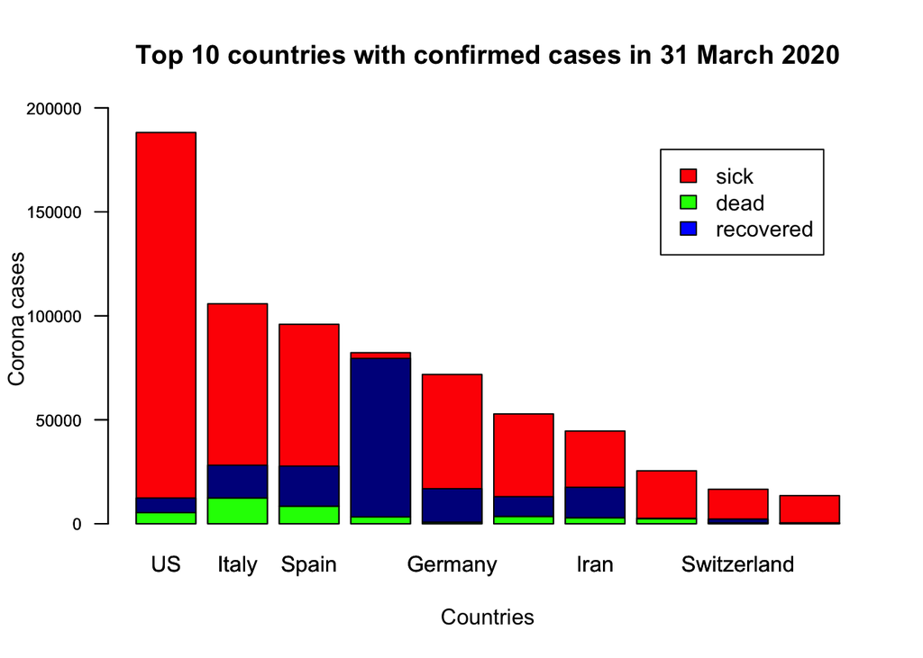

```r
cases = matrix (c(joined_top$Cases, joined_top$Died, joined_top$Recovered), nrow=10, ncol=3)
rownames(cases)= c(as.character(joined_top$Country.Region))
colnames(cases) = c('Cases','Died','Recovered')
cases.t = t(cases)
{cases.plot = barplot(cases.t[1,], ylab = "Corona cases ", xlab= "Countries", main = "Top 10 countries with confirmed cases in 31 March 2020", width= 0.5,  cex.axis = 0.75, cex.lab= 1, las= 1, col = "red", ylim= c(0,200000))
others.plot = barplot(cases.t[2:3,], width= 0.5, cex.axis = 0.75, cex.lab= 1, las= 1, col=c("green","dark blue"), add = T)
legend(4.5, 180000, c("sick", "dead", "recovered"), fill= rainbow(3))}
```

### Q2

### Analysis of Daily New Corona Cases and Deaths

20 points

The two datasets (Corona Cases and Deaths) register the value of cases and deaths, respectively, as a cumulative sum for each day. In this question we would like to understand the daily differences between consecutive days.

1. Add a new column named `Diff` to both the `cases.agg` and the `deaths.agg` data-frames. This new column should register the daily `Value` difference for each country. In other words, the `Diff` column shows how many new cases/deaths each country incurs every day. Hint - diff must be per country. (7pts)
2. Find the top 10 instances of country and date combinations with the greatest absolute number of new daily Corona cases and deaths (separately). Print the result in a descriptive format. (5pts)
3. In one figure, plot Italy’s new daily Corona cases AND deaths as a function of Date. Choose the plot type you think that makes the most sense. (3pts)
4. Plot the same graph as in (c), but this time plot the number of new cases on the logarithm scale. What can we learn? (5pts)

**Solution:**

```r
#finding the difference between days on agg.data#
top.diff.cases = agg[[1]] %>% group_by(Country.Region) %>%  mutate(diff.cases = Value - lag(Value, default = 0)) %>% select('Country.Region', 'Date', 'diff.cases') %>% ungroup %>% top_n(10, diff.cases)
top.diff.death = agg[[2]] %>% group_by(Country.Region) %>%  mutate(diff.death = Value - lag(Value, default = 0)) %>% select('Country.Region', 'Date', 'diff.death') %>% ungroup %>% top_n(10, diff.death)
#Print the result in a descriptive format#
print(top.diff.cases)
```

```
## # A tibble: 10 x 3
##    Country.Region Date       diff.cases
##    <fct>          <fct>           <dbl>
##  1 US             2020-04-03      31745
##  2 US             2020-04-04      33283
##  3 US             2020-04-08      31533
##  4 US             2020-04-09      34126
##  5 US             2020-04-10      33755
##  6 US             2020-04-16      31242
##  7 US             2020-04-17      32114
##  8 US             2020-04-18      32491
##  9 US             2020-04-24      36188
## 10 US             2020-04-25      32796
```

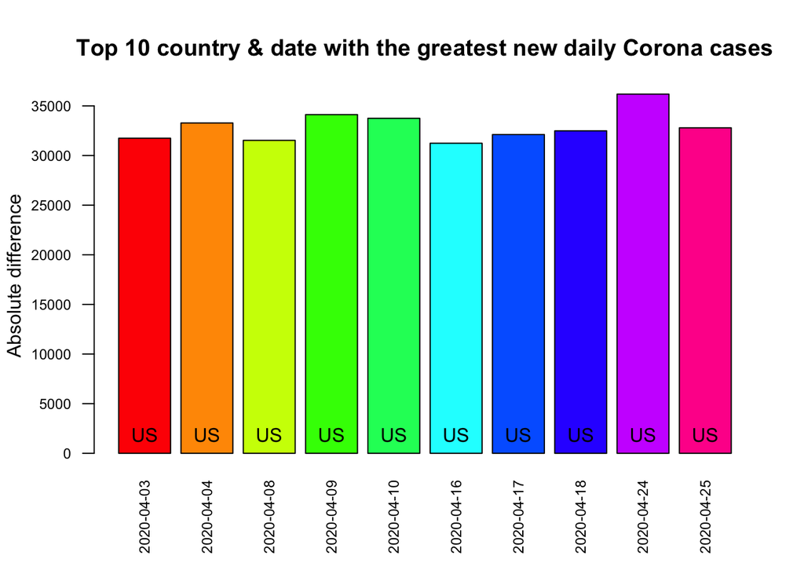

```r
{x= barplot(top.diff.cases$diff.cases, names.arg = top.diff.cases$Date, main= 'Top 10 country & date with the greatest new daily Corona cases', ylab= 'Absolute difference', las=2,  cex.axis = 0.75, cex.names= 0.75, col= rainbow(10))
text(x, 0 ,top.diff.cases$Country.Region, cex=1, pos=3, col='black')
}
```

```r
print(top.diff.death)
```

```
## # A tibble: 10 x 3
##    Country.Region Date       diff.death
##    <fct>          <fct>           <dbl>
##  1 US             2020-04-07       2297
##  2 US             2020-04-14       2392
##  3 US             2020-04-15       2472
##  4 US             2020-04-17       2584
##  5 US             2020-04-18       2342
##  6 US             2020-04-21       2427
##  7 US             2020-04-22       2326
##  8 US             2020-04-23       2312
##  9 US             2020-04-25       2262
## 10 US             2020-04-29       2612
```

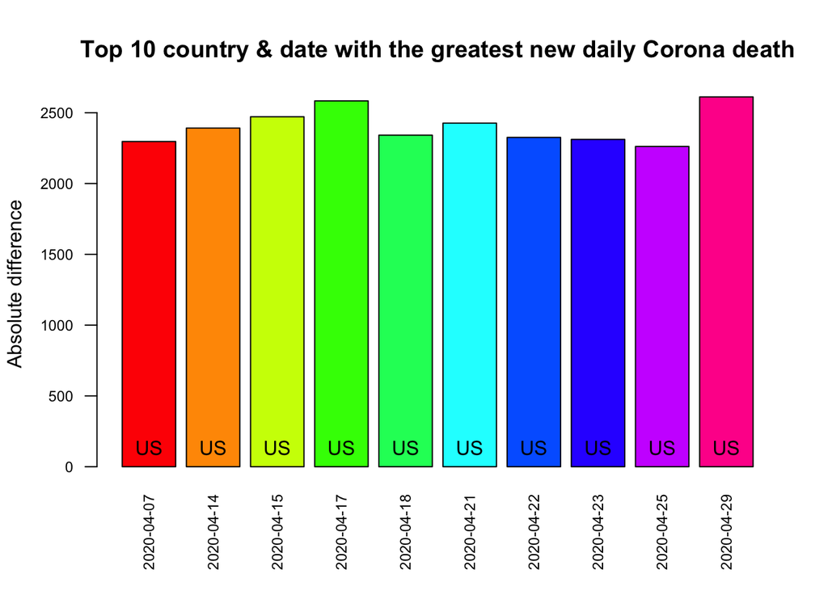

```r
{y= barplot(top.diff.death$diff.death, names.arg = top.diff.death$Date, main= 'Top 10 country & date with the greatest new daily Corona death', ylab= 'Absolute difference', las=2, cex.axis = 0.75, cex.names= 0.75, col= rainbow(10))
text(y, 0 ,top.diff.death$Country.Region, cex=1, pos=3, col='black')
}
```

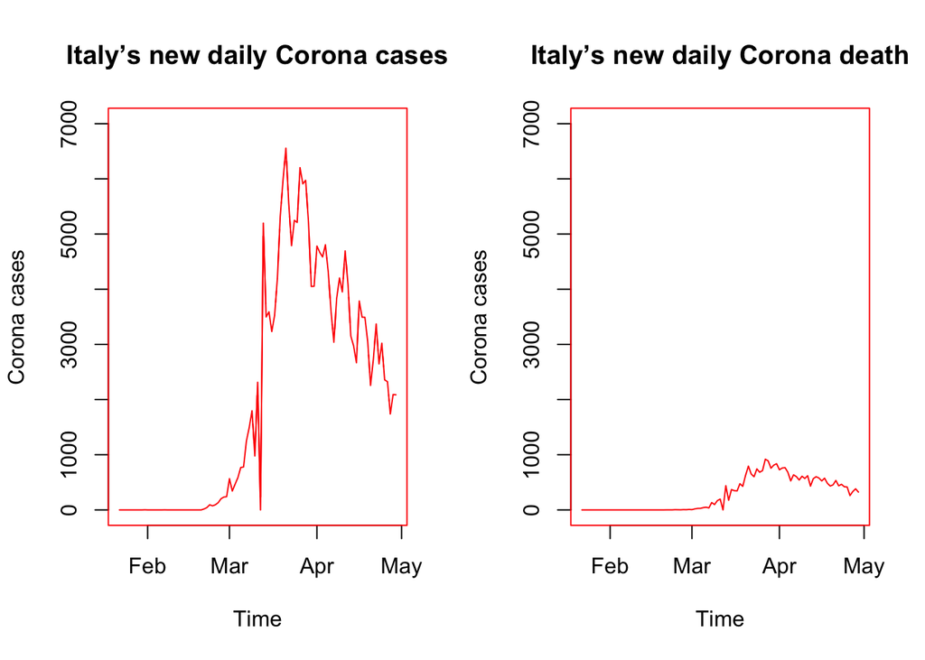

```r
#plot Italy’s new daily Corona cases AND deaths as a function of Date#
italy.cases = agg [[1]] %>% filter (Country.Region == 'Italy') %>%  mutate(diff.cases = Value - lag(Value, default = 0)) %>% select('Date', 'diff.cases')
italy.death = agg[[2]] %>% filter (Country.Region == 'Italy') %>%  mutate(diff.death = Value - lag(Value, default = 0)) %>% select('Date', 'diff.death')
italy.cases$Date = as.Date(italy.cases$Date)
italy.death$Date = as.Date(italy.death$Date)
par(pch=22, col="red")
par(mfrow=c(1,2))
{plot(italy.cases$Date, italy.cases$diff.cases, type ="c", main = 'Italy’s new daily Corona cases', xlab = 'Time', ylab = 'Corona cases', ylim=c(0,7000))
lines(italy.cases$Date, italy.cases$diff.cases, type="l")}
{plot(italy.death$Date, italy.death$diff.death, type ="c", main = 'Italy’s new daily Corona death', xlab = 'Time', ylab = 'Corona cases', ylim=c(0,7000))
lines(italy.death$Date, italy.death$diff.death, type="l")}
```

### Q3

### Preparing and Analyzing the World Bank Data

25 points

1. Rename the columns of `eco_data`: `country,S_country,feature,feature_code,Y2018V,Y2019V`. (2pts)
2. Create a new `eco` data-frame whose dimensions are $266 \times 11$. The first column should include the names of the countries in `eco_data.`  
   The rest of the columns should be the features with their respective values in `eco_data` for each country from 2018. Print the head of the new data-frame.(8pts)
3. Select and rename the following columns: `country` as country, `GDP(US currency)` as GDP, `Population ages 65 and above (% of total population)` as pop65, `Population in the largest city (% of urban population)` as pop_city_ratio, `Population, total` as pop_total columns . (2pts)
4. Show a table of the five countries with the highest per capita GDP in 2018.  
   Next (considering all countries), plot the % of population over 65 vs. log of GDP per capita in 2018, after excluding the 10% countries with the lowest GDP per capita. Using `lm` and `abline`, add a regression line to the plot. What is your conclusion? (13 pts)

**Solution:**

```r
#loading the `eco_data`:
eco_data <- read.csv(url("https://raw.githubusercontent.com/DataScienceHU/DataAnalysisR_2020/master/data/economic_data.csv"))
```

### a

```r
names(eco_data) <- c("country", "S_country", "feature", "feature_code", "Y2018V", "Y2019V")
eco_data$Y2018V = as.numeric(as.character(eco_data$Y2018V))
```

### b

Create new data frame eco using dplyr functions such like select, filter and spread. New data frame eco contains 11 columns. Firsr column is a country and others are features. Rows contains values for each country.

```r
eco = eco_data %>% select(country, feature, Y2018V) %>% filter(as.character(feature) != "") %>% spread(feature, Y2018V)
head(eco)
```

```
##          country GDP (constant LCU) GDP (current US$)
## 1    Afghanistan       5.114325e+11       19362969582
## 2        Albania       1.513259e+12       15102500898
## 3        Algeria       6.123376e+12      173757952824
## 4 American Samoa       6.080000e+08         636000000
## 5        Andorra       2.002840e+09        3236543909
## 6         Angola       1.552771e+12      105750987619
##   GDP, PPP (current international $)
## 1                        72672245387
## 2                        38306694289
## 3                       653771569286
## 4                                 NA
## 5                                 NA
## 6                       198795526982
##   Government expenditure on education, total (% of GDP)
```

[output cut: 41 more lines]

### c

Rename and select using dplyr function select

```r
eco = eco %>% select(country,
                     GDP = `GDP (current US$)`,
                     pop_total = `Population, total`,
                     pop_city_ratio = `Population in the largest city (% of urban population)`,
                     pop65 = `Population ages 65 and above (% of total population)`)
```

### d

```r
#1
eco_gdp = eco %>% arrange(desc(GDP)) %>% filter(!is.na(GDP)) %>% filter(!is.na(GDP))
head(eco_gdp, n = 10)
```

```
##                      country          GDP  pop_total pop_city_ratio     pop65
## 1                      World 8.590973e+13 7594270356       16.10730  8.873442
## 2                High income 5.420574e+13 1210312147       19.40955 17.932044
## 3               OECD members 5.267622e+13 1303529456       17.71054 17.118618
## 4  Post-demographic dividend 5.009029e+13 1109997273       17.47900 18.954517
## 5           IDA & IBRD total 3.269441e+13 6412522234       15.23097  7.224821
## 6        Low & middle income 3.173561e+13 6383958209       15.09834  7.156651
## 7              Middle income 3.114946e+13 5678540888       13.89937  7.637015
## 8                  IBRD only 3.047324e+13 4772284113       12.46695  8.483780
## 9        East Asia & Pacific 2.594241e+13 2328220870       11.65338 10.744358
## 10       Upper middle income 2.444613e+13 2655635719       12.28765 10.037949
```

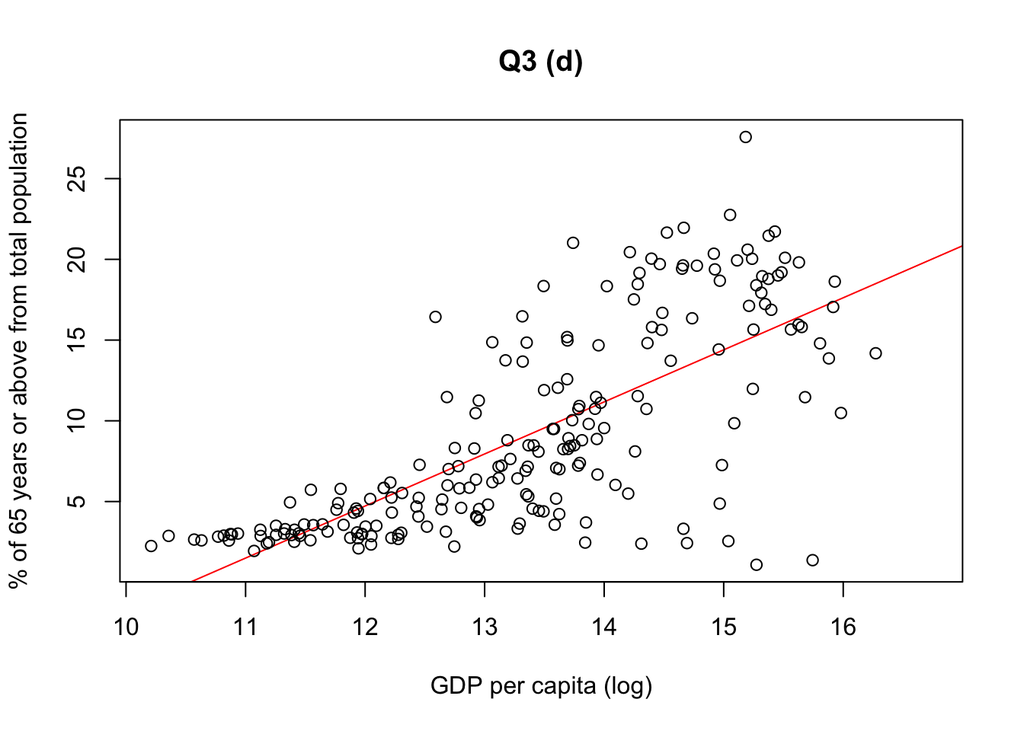

```r
#2
eco_gdp_90 = eco_gdp %>% mutate(logGDP_per_capita = log((GDP/pop_total)*100)) %>% head(n = round(length(eco_gdp$country)*0.9))

#3
lm_pop65 <-lm(formula = as.vector(eco_gdp_90$pop65) ~ as.vector(eco_gdp_90$logGDP_per_capita))
plot(x = eco_gdp_90$logGDP_per_capita, y = eco_gdp_90$pop65,
     main = "Q3 (d)",
     xlab = "GDP per capita (log)",
     ylab = "% of 65 years or above from total population",
     abline(lm_pop65, col = "red"))
```

### Q4

### Joining the Datasets

20 points

1. Join the `deaths.agg`, `cases.agg`, and `recovered.agg` into one data-frame called `corona`.(5pts)
2. Join the `corona` and `eco` data-frames in a way that will keep the most information regarding the data (but not full join).  
   Make sure that no essential data is thrown away (show this). (3pts)
3. Create new columns of normalized `cases`, `deaths`, and `recovered` so they will show the number of cases per 100,000 people for each country.  
   Using the last day of March as a reference, create a single stacked bar plot that visualizes the top 10 countries in terms of normalized Corona cases, and their respected normalized Corona deaths and recovered, as done in Q1.  
   how is it different from the graph before normalization? (5pts)
4. Using the last day of March as a reference, create a scatter-plot of normalized deaths and cases vs. `pop65`. Limit the plot to show only countries with 15% or more of `pop65`.  
   In addition, color the outliers( pop65>24, norm100K_deaths>15) in that plot in red and add to the plot their country names (7pts)

**Solution:**

### a

Joining three datas frame using bind_cols and rename

```r
corona = agg[[1]] %>% bind_cols(select(agg[[2]], Value)) %>% bind_cols(select(agg[[3]], Value)) %>% rename(cases = Value, deaths = Value1, recovered = Value2)
```

### b

In order not to lose essentail data we decided to use the countries abbreviations from the original eco_data and to add abbreviations to the corona data-set.

```r
codes_corona = c()
k = 1
for (i in as.character(corona$Country.Region)){
  codes_corona[k] <- as.character(data_con$ISO.3166.1.Alpha.3.Codes[which(i == as.character(data_con$Country.Region))][1])
  k<- k+1
}
corona = corona %>% mutate(S_country = codes_corona)
eco_code = eco_data %>% select(S_country, feature, Y2018V) %>% filter(as.character(feature) != "") %>% spread(feature, Y2018V)  %>%  select(S_country, GDP = `GDP (current US$)`, pop_total = `Population, total`, pop_city_ratio = `Population in the largest city (% of urban population)`, pop65 = `Population ages 65 and above (% of total population)`)
x = setdiff(corona$S_country, eco_code$S_country)
y= c("Vatican", "Kosovo", "Taiwan", "Westren Sahara")
print(paste("Missing data for ", c(x[2:5]),"-", y[1:4]))
```

```
## [1] "Missing data for  VAT - Vatican"
## [2] "Missing data for  RKS - Kosovo"
## [3] "Missing data for  TWN - Taiwan"
## [4] "Missing data for  ESH - Westren Sahara"
```

After we showed we will we kept most of the data we can use inner join to join eco_code and corona by S_country

```r
corona_eco = corona %>% inner_join(eco_code, by = 'S_country')
```

### c

1. Using mutate we creating three new colums.
2. Build par plot similary to Q1. We can see that even if a country occupies a high position in terms of the number of confurmed cases, this does not mean that there is a large number of confurmed cases per 100000. It is depends of total populatin in the country.

```r
#1
corona_eco = corona_eco %>% mutate(norm_cases = (cases/pop_total)*100000) %>% mutate(norm_recovered = (recovered/pop_total)*100000) %>% mutate(norm_deaths = (deaths/pop_total)*100000)

#2
corona_eco_march = corona_eco %>% filter(Date == "2020-03-31") %>% arrange(desc(norm_cases)) %>% top_n( 10, norm_cases) %>% select(Country.Region, norm_cases, norm_deaths, norm_recovered)

cases_norm = matrix (c(corona_eco_march$norm_cases, corona_eco_march$norm_deaths, corona_eco_march$norm_recovered), nrow=10, ncol=3)
rownames(cases_norm)= c(as.character(corona_eco_march$Country.Region))
colnames(cases_norm) = c('norm_cases','norm_died','norm_recovered')
print(cases_norm)
```

```
##               norm_cases  norm_died norm_recovered
## San Marino      698.5349 76.9572295      38.478615
## Andorra         488.2736 15.5832013      12.986001
## Luxembourg      358.3840  3.7845878      13.163784
## Iceland         321.0078  0.5656525      55.999593
## Spain           205.2982 18.1149847      41.218867
## Switzerland     194.9735  5.0842226      21.405399
## Liechtenstein   179.3722  0.0000000       0.000000
## Italy           175.0616 20.5655074      26.027910
## Monaco          134.4295  2.5851817       5.170363
## Austria         115.0668  1.4468121      12.377025
```

[figure not shown]

```r
cases_norm.t = t(cases_norm)
{cases.plot = barplot(cases_norm.t[1,], ylab = "Corona cases per 10000 population", xlab= "Countries", main = "Top 10 countries with normalized cases in 31 March 2020", width= 0.5,  cex.axis = 0.75, cex.lab= 1, las= 1, col = "red", ylim= c(0,1000))
others.plot = barplot(cases_norm.t[2:3,], width= 0.5, cex.axis = 0.75, cex.lab= 1, las= 1, col=c("green","dark blue"), add = T)
legend(4.5, 800, c("sick", "dead", "recovered"), fill= rainbow(3))}
```

## The scale of normalized cases is significanctly lower and the top 10 countries are different.

### d

First we create data frame to make work easily. Then we build plot using basic graph function.

```r
corona_eco_plot = corona_eco %>% filter(pop65 >= 15) %>% filter(Date == "2020-03-31") %>% select(Country.Region, norm_cases, norm_deaths, norm_recovered, pop65)
print(corona_eco_plot)
```

```
##            Country.Region norm_cases norm_deaths norm_recovered    pop65
## 1               Australia  18.241568  0.07202198     1.43243724 15.65648
## 2                 Austria 115.066773  1.44681208    12.37702521 19.00157
## 3                Barbados  11.861527  0.00000000     0.00000000 15.80269
## 4                 Belgium 111.844895  6.17226233    14.84844951 18.78874
## 5  Bosnia and Herzegovina  12.635649  0.39110342     0.51144293 16.47032
## 6                Bulgaria   5.680349  0.11389171     0.24201989 21.02191
## 7                  Canada  23.009345  0.27253944     4.29586925 17.23201
## 8                 Croatia  21.201154  0.14672079     1.63838216 20.44543
## 9                    Cuba   1.640481  0.05291874     0.07055832 15.18621
## 10                Czechia  31.132081  0.29174562     0.42350171 19.42088
## 11                Denmark  52.419634  1.55240773     1.32817106 19.81295
## 12                Estonia  56.401622  0.30282750     1.96837875 19.62636
## 13                Finland  25.697484  0.30807985     0.18122344 21.72079
## 14                 France  78.861283  5.27264564    14.20121120 20.03462
```

[output cut: 23 more lines]

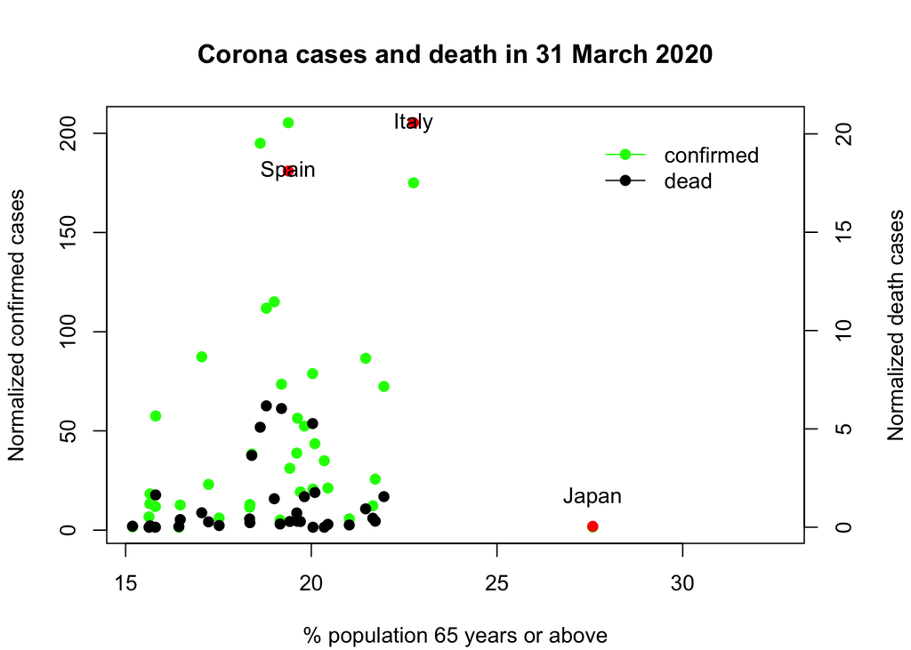

```r
#making the plot#
par(mar=c(4, 4, 4, 4) + 0.1)
plot(corona_eco_plot$pop65, corona_eco_plot$norm_cases,
      xlab= "% population 65 years or above",
      ylab= "Normalized confirmed cases",
      main= "Corona cases and death in 31 March 2020",
      pch=19,
     col="green",
     ylim=c(min(corona_eco_plot$norm_cases), max(corona_eco_plot$norm_cases)),
     xlim=c(min(corona_eco_plot$pop65), max(corona_eco_plot$pop65)+5))
par(new=TRUE)
plot(corona_eco_plot$pop65, corona_eco_plot$norm_deaths, pch= 19,  xlim=c(min(corona_eco_plot$pop65), max(corona_eco_plot$pop65)+5), axes=F, xlab="", ylab="", col = ifelse(corona_eco_plot$norm_deaths > 15 | corona_eco_plot$pop65 > 24, "red", "black"))
axis(4)
mtext("Normalized death cases", line=3, side=4)
legend("topright", c("confirmed", "dead"), box.lty = 0, lty=1, pch=19, col=c("green", "black"), inset=0.05)
text(corona_eco_plot$pop65[which(corona_eco_plot$pop65 > 24)],
     corona_eco_plot$norm_cases[which(corona_eco_plot$pop65 > 24)],
     labels = corona_eco_plot$Country.Region[which(corona_eco_plot$pop65 > 24)])
text(corona_eco_plot$pop65[which(corona_eco_plot$norm_deaths > 15)],
     corona_eco_plot$norm_deaths[which(corona_eco_plot$norm_deaths > 15)],
     labels = corona_eco_plot$Country.Region[which(corona_eco_plot$norm_deaths > 15)])
```

### Q5

### Open Question

10 points

Write an interesting research question regarding the Corona outbreak and then follow the steps to answer it using tables and plots. You can use the loaded datasets or any other dataset you find as long as you add the data file to your `lab1` repository so it can be loaded directly from a `url` (e.g. the World Bank). This question will be graded based on creativity, originality, and the novelty of the analysis.

**Solution:**

```r
CHE_data = read.csv(url("https://raw.githubusercontent.com/DataScienceHU/52414-lab-1-dragunskaia_katya_and_revel-vilk_shoshi/master/API_SH.XPD.CHEX.PC.CD_DS2_en_csv_v2_1001395.csv"))
CHE_data = CHE_data %>%  select(S_country= Country.Code, CHE2017 = X2017)
```

#creating a dataset of risk of death in the last day of corona_eco data. We limitted the database for a risk of death higher than 1% and countries with more than 1000 cases.

```r
corona_eco$Date  = as.Date(corona_eco$Date)
latest = max(corona_eco$Date)
death_risk = corona_eco %>% filter(Date == latest) %>% mutate(risk= deaths/cases*100) %>%  mutate(GDP_capita= GDP/pop_total) %>% filter(risk > 1) %>% filter(cases >1000) %>%  select(Country.Region, S_country, Date, risk, cases, deaths, GDP_capita, pop_total, pop_city_ratio, pop65)
```

# joining the risk_corona and CHE data

```r
Q5 = death_risk %>% left_join(CHE_data, by = 'S_country') %>% mutate(logCHE = log(CHE2017))
```

#creating the plot

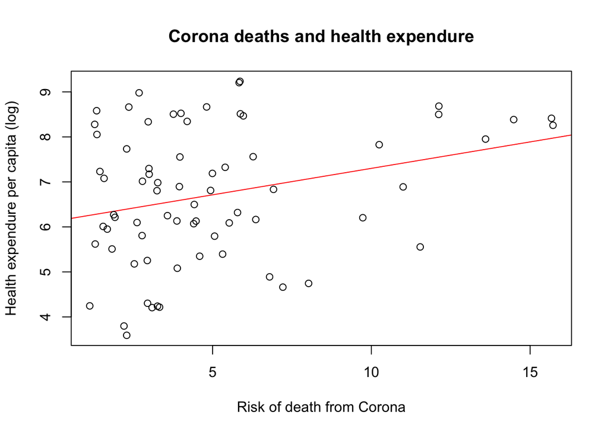

```r
lm_CHE <-lm(formula = as.vector(Q5$logCHE) ~ as.vector(Q5$risk))
corr = cor.test(x= Q5$risk, y= Q5$logCHE)
plot(x= Q5$risk, y= Q5$logCHE, main= "Corona deaths and health expendure", xlab = "Risk of death from Corona", ylab = "Health expendure per capita (log)", abline(lm_CHE, col = "red"))
```

```r
print("Increased health expendure per capita in 2017 is weakly correlated with higher risk of death from Corona")
```

```
## [1] "Increased health expendure per capita in 2017 is weakly correlated with higher risk of death from Corona"
```

```r
print(corr)
```

```
##
##  Pearson's product-moment correlation
##
## data:  Q5$risk and Q5$logCHE
## t = 2.4633, df = 69, p-value = 0.01626
## alternative hypothesis: true correlation is not equal to 0
## 95 percent confidence interval:
##  0.05463309 0.48541827
## sample estimates:
##       cor
## 0.2843129
```